# Introdução à R para Cientistas sociais

Seminário Discente IESP-UERJ 2023

Luana Calzavara - Doutorando em Ciência Política IESP-UERJ - luacalzavara@iesp.uerj.br

08/11/23

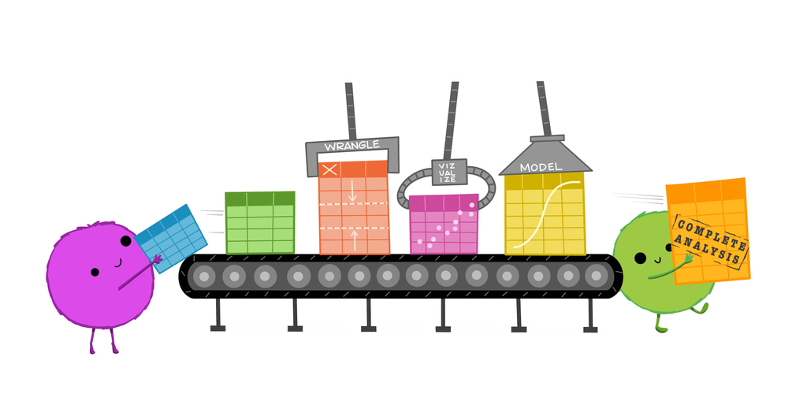

Possibilidades no R - Fonte: “Illustrations from the Openscapes blog Tidy Data for reproducibility, efficiency, and collaboration by Julia Lowndes and Allison Horst”, dispinível em https://allisonhorst.com/other-r-fun

## Objetivo do curso

Introdução a R inclui ter noções de programação, conhecer o ambiente do Rstudio e se familiarizar com funções de manuseio de data-sets.

- R: gratuito e *open source*. Uma linguaguem que permite aos usuários manipular dados, realizar operações, construir modelos estatísticos, mapas, dashboards, e milhares de outras funcionalidades. Muito importante para reprodutibilidade na ciência.

### Conhecendo do RStudio

O RStudio é o ambiente de desenvolvimento onde iremos utilizar a linguagem R.

## Fundamentos da programação

Antes de tudo, quando estamos utilizando R, é bom que possamos compreender o que é programar. De forma simplificada, o que estamos fazendo é nos comunicar com o computador de forma eficaz, para que ele nos retorne o que precisamos no decorrer de nossas pesquisas.

Porém, o computador não entende português, inglês, etc. O que ele entende são *bits*. Nesse sentido, a ciência da computação desenvolve e trabalha com diferentes tipo de linguagens para seus projetos, com diferentes objetivos.

- Diferente de programas como o Excel onde você utiliza o *point-clik* para fazer alterações em uma planilha, com linguagem de programação, nós escrevemos códigos, rotinas, *scripts*, onde descrevemos os comandos que desejamos operacionalizar. E isso é importante pois nos permite *reprodutibilidade*.
- Esses códigos, como qualquer outra língua, obedece a certas regras. Nesse caso, estamos produzindo **Algoritimos**
- Escrever um código é como escrever um texto:
1. Você precisa conhecer a língua do seu interlocutor para efetivar a comunicação
2. O que está sendo escrito precisa ter coesão, precisa ter lógica para ser compreendido

**Lógica de programação** são estruturas comuns à todas as linguagens de programação. Seja ela R, Python, C++, JAVA, etc

Podem tem diferentes formas de escrita, algumas com mais possibilidades e aplicabilidade que outras, mas possuem as mesmas lógica. Contruimos, então, **algoritmos** em nossos *scripts* para comunicar ao R o que queremos fazer.

- **Algoritimos** são, por tanto, instruções, como receitas de bolo ou um manual, que traduz passa-a-passo o que deve ser feito. As indicações devem estar escritas em um sequência *lógica*

Devemos nos atentar a dar insturções exatas do que deve ser feito, como podemos ver em [nesse vídeo.](https://www.youtube.com/watch?v=pdhqwbUWf4U&t=179s)

Para nos auxiliar na escritas dos *algoritmos*, existem certos operadores:

### Operadores aritiméticos

São símbolos matemáticos que nos permitem fazer operações aritméticas, como soma, subtração, etc.

| Operador | Símbolo |
| --- | --- |
| Adição | + |
| Subtração | - |
| Multiplicação | * |
| Divisão | / |
| Exponenciação | ^ ou ** |
| Módulo | %% |

- Exemplos:

```r
5 + 5
```

```
## [1] 10
```

```r
48 - 5
```

```
## [1] 43
```

```r
8 * 5
```

```
## [1] 40
```

```r
35 / 5
```

```
## [1] 7
```

```r
9 ^ 2
```

```
## [1] 81
```

```r
9 ** 2
```

```
## [1] 81
```

```r
10 %% 2
```

```
## [1] 0
```

```r
11 %% 2
```

```
## [1] 1
```

### Operadores relacionais (ou de comparação)

Operadores relacionais são utilizados para podermos comparar duas variáveis. Tambem usamos para verificar se uma proposição é verdadeira ou não. São eles:

| Operador | Símbolo |
| --- | --- |
| Igual | == |
| Diferente | != |
| Maior | > |
| Maior ou igual | >= |
| Menor | < |
| Menor ou igual | <= |

- Exemplos:

```r
8 > 5
```

```
## [1] TRUE
```

```r
6 < 10
```

```
## [1] TRUE
```

```r
(4+6) == (5+5)
```

```
## [1] TRUE
```

```r
(4+6) == (5+10)
```

```
## [1] FALSE
```

```r
(4+6) != (5+5)
```

```
## [1] FALSE
```

```r
7 >= (4 + 3)
```

```
## [1] TRUE
```

### Operadore lógicos

Os operadores lógicos se conectam com os operadores relacionais na medida em que o resultado de tais comparações são definidos como verdareiros, *TRUE*, ou falsos, *FALSE*. Estes são valores lógicos, ou booleanos, resultado de testes, de verificações.

Os operadores lógicos significam: “e”, teste simultâneo de duas condições (sendo verdadeiro quando ambas as condições são verdadeiras);“não”, negação do valor booleano e “ou”, teste alternativo, em que apenas uma das condições precisa ser verdadeira para retornar, TRUE.

| Operador | Símbolo |
| --- | --- |
| E | & |
| Ou | \| |
| Não | ! |

- Exemplos:

```r
4 & 8 > 1
```

```
## [1] TRUE
```

```r
4 | 8 > 5
```

```
## [1] TRUE
```

- Os operadores nos auxilião a manter a coesão da linguagem, a direcionar o R, a dar as instruções corretas. Quando escrevemos um código, queremos que fique claro o que deve ser feito.

## Estruturas Sequenciais

### Estruturas de decisão : se-então-senão

Esta estrutura, basicamente, é utilizada para avaliar uma expressão lógica, determinando se ela é *TRUE* ou *FALSE*. Caso seja verdadeira, um comando é executado. Logo, é uma estrutura *condicional*. Pro exemplo: O comando *a* só pode ocorrer, se a estrutura lógica *b* for verdadeira.

Exemplo condicional – Quando utilizamos o if, a estrutura lógica em parênteses é verificada pelo R. Se a condição é atendida, se ela é verdadeira, o passo seguinte que está contido dentro das “{ }”chaves é realizado.

A estrutura é: if (condição) {comando a ser executado se a condição for verdadeira}

- Exemplos:

```r
x <- (-5)

if (x < 0){
  z <- (-x)
}

print(z)
```

```
## [1] 5
```

E quando a condição não é atendida ?

```r
# x <- 5
#
# if (x < 0){
#   y <- (-x)
# }
#
# print(y)

# Error in print(y) : object 'y' not found
```

Nessas situações, um ERROR surge, porque o R não conseguiu completar a operação. Uma alternativa que temos é utilixar *else*:

```r
x <- (5)

if (x < 0){

  y <- -x
  print(y)

} else {

    print("o valor de x não é negativo")
}
```

```
## [1] "o valor de x não é negativo"
```

```r
votos <- 800

if (votos > 700){
  status <- "eleito"
} else{
  status <- "não eleito"
}

print(status)
```

```
## [1] "eleito"
```

Adicionando mais uma condição

```r
if (votos > 1200){
  status <- "eleito"
} else if (votos > 700  & votos <= 1200){
  status <- "suplente"
} else {
  status <- "nao eleito"
}

print(status)
```

```
## [1] "suplente"
```

### Estrutura de repetição: *for loop*

**for loop**: significa, para todo i, de a até b, realize o seguinte comando. Para todos os elementos contidos na sequência indicada entre parêntese, faça a seguinta tarefa. Repita tal operação até que todos os casos da sequência delimitada seja findada.

Geralmente usamos i como contador, mas pode adotar qualquer nome. No nosso exemplos, utilizamos a ‘sigla’ como contador dentro da sequência denominada ‘partidos’, que contém um total de 5 siglas.

```r
partidos <- c("pt", "psol", "pv", "pl", "psdb")
for (sigla in partidos) {
  print(sigla)
}
```

```
## [1] "pt"
## [1] "psol"
## [1] "pv"
## [1] "pl"
## [1] "psdb"
```

```r
for (sigla in partidos) {
  sigla <- toupper(sigla)
  print(sigla)
}
```

```
## [1] "PT"
## [1] "PSOL"
## [1] "PV"
## [1] "PL"
## [1] "PSDB"
```

## Objetos

O R é uma linguagem orientada a objetos. E é com eles que trabalhamos, basicamente. Objetos são onde guardamos informações. Quando criamos um, ele aparece no nosso “Environment”. Porém, elas ainda estão apenas na memória do R, e não no seu computador. Objetos podem ser vetores, data.frames, listas, etc. Quais quer informações guardadas para serem usadas novamente, são objetos.

```r
obj_unico <- 2
```

Quando temos essas informações guardadas, podemos realizar operação entre elas. Isto nos permite que realizemos operações entre elas.

O símbolo **<-**, seta para a esquerda, significa *atribuição*. No windows, o atalho de teclado para utilizá-lo é “Alt -”.

```r
z <- 10
z
```

```
## [1] 10
```

No código acima, lê-se “armazenar o valor 10 no objeto z, ou z recebe o valor 10”.

Podemos também guardar o resultado de operações matemáticas em objetos.

```r
soma <- 5 + 5
soma
```

```
## [1] 10
```

```r
x <- 5
y <- 3

x + y
```

```
## [1] 8
```

```r
x - y
```

```
## [1] 2
```

```r
x / y
```

```
## [1] 1.666667
```

```r
x * y
```

```
## [1] 15
```

Também podemos armazenaro o resultado de uma função em um objeto

```r
b <- sqrt(81)
```

```r
b
```

```
## [1] 9
```

- Como nomear objetos:
1. Não pode começar com números.
2. Tente ser consiso e sintético sobre o que se trata o objeto
3. O R é *case-sensitive*, então “a” !=(é diferente) “A”.
4. Existem formas como utilização: minha_base , minhaBase, MinhaBase

## Vetores

Vetores são formas uma forma contínua de armazenamento de memória do mesmo tipo de dado. Vetores são como fileiras de objetos, que pode conter apenas um, ou milhares dele. Quando vetor tem apenas *uma* informação, ele é um vetor atômico, ou unitário, um objeto simples. Todas as informação em R são guardadas em forma de vetor.

```r
c(1,5,7,9)
```

```
## [1] 1 5 7 9
```

```r
c("pt", "psol", "pv", "pl", "psdb")
```

```
## [1] "pt"   "psol" "pv"   "pl"   "psdb"
```

```r
1:20
```

```
##  [1]  1  2  3  4  5  6  7  8  9 10 11 12 13 14 15 16 17 18 19 20
```

```r
seq(12,1)
```

```
##  [1] 12 11 10  9  8  7  6  5  4  3  2  1
```

```r
vetor1 <- c(2, 4, 6, 8, 10) #vetor com números inteiros
vetor2 <- c(2, "2", "dois") # vetor onde o R lê todos os dados como caracteres.
```

```r
class(vetor1)
```

```
## [1] "numeric"
```

```r
class(vetor2)
```

```
## [1] "character"
```

## Funções

O R possui funções que vem originalmente instaladas, ou acrescentadas segundo pacotes que os seus usuários desenvolvem. Funções são como ‘caixas transformadoras’, onde você fornece uma ou mais informação, que são chamados de *argumentos* ou *parâmetros*, e te devolvem um resultado.

- Exemplo, funções básicas pré-instaladas no R

```r
sum(5,5)
```

```
## [1] 10
```

```r
log(8)
```

```
## [1] 2.079442
```

```r
sqrt(81)
```

```
## [1] 9
```

As funções são seguidas (), parênteses, onde são expressos os argumentos necessários para executar tal função.

- Podemos aplicar função sobre os vetores

```r
vetor3 <- c(0.382,0.714,0.926,0.149,0.537,0.893,0.245,0.661,0.428,0.775)
vetor3
```

```
##  [1] 0.382 0.714 0.926 0.149 0.537 0.893 0.245 0.661 0.428 0.775
```

Podemos calcular a média:

```r
mean(vetor3)
```

```
## [1] 0.571
```

o desvio padrão:

```r
sd(vetor3)
```

```
## [1] 0.2669915
```

### Pedindo ajuda

```r
?tolower
```

```
## starting httpd help server ... done
```

```r
help("tolower")
```

## Manipulanndo bases de dados

O R é muito utilizado como um recurso para análise de dados. Podemos criar bases de dados dentro do próprio R, ou importá-las. Como nosso tempo é curto e como na maioria das vezes os dados vem de fontes externas como, por exemplo, IBGE ou TSE, vamos importar uma base.

### Data.frame

OK. Mas o que são base de dados ? No R, as bases são chamadas de *data.frame*. São estruturas que armazenam informações, onde cada coluna é uma variável, e cada linha é uma observação. *Data.frame* são matrizes, onde cada coluna é um vetor. O que nos permite, posteriormente, museálas e aplicar funções sobre.

Por exemplo:

| Ano eleitoral | Candidato | Partido | Votos |
| --- | --- | --- | --- |
| 2022 | Claudio Castro | PL | 4.930.288 |
| 2022 | Marcelo Freixo | PSB | 2.300.980 |
| 2022 | Rodrigo Neves | PDT | 672.291 |
| 2022 | Paulo Ganime | NOVO | 446.580 |

### Abrindo arquivos no R

#### Primeiro,vamos ter certeza de onde estamos.

- Em nosso minicurso, teremos como exemplo a manipulação da base de dados referente ao resultado eleitoral no Acre em 2018.

Localizar a pasta em que estamos trabalhando nos ajuda a importar o dados com mais facilidade. O ideal é que tenhamos scripts e arquivos no mesmo *workspace*, na mesma pasta de trabalho dentro do seu computador, para facilitar a importação e exportação de arquivos.

- Vamos descobrir em qual pasta estamos trabalhando no momento

```r
getwd() # diz a localização atual
```

```
## [1] "C:/Users/Lua/Documents/GitHub/minicurso_R"
```

Se quisermos redirecionar para uma outra pasta.

```r
# setwd()
```

Observem qeu eu usei o “#” e a função mudou de cor. Isso acontece porque eu *comentei* o código. Durante a nosso script, eu posso usar a “#” para duas coisas: 1. para fazer comentário, como no caso mais acima do *getwd*, ao lando da função 2. Se eu não quero rodar alguma função, eu comento ela, como no exemplo de *setwd*.

No meu caso, como eu não quero alterar a pasta de trabalho, eu deixei a função comentada com uma “#”.

## Instalação de pacotes

O R possui funções já instaladas nele, o *base R*. Mas o legal dele é que há uma gama de funções desenvolvidas por usuárias, compiladas em pacotes (ou *packages*, em inglês), que estão disponível para download. Você mesmo pode desenvolver um. Elas estão armazenadas no CRAN (Comprehensive R Archive Network) ou no Github. Os pacotes expandem as capacitades do R.

Vamos instalar 2 pacotes que nos auxiliam no manuseio de dados:

```r
# install.packages("rio") Pacote que nos auxilia a importar e exportar dados de diveros tipos


# install.packages("tidyverse") # um pacote que contém vários pacotes dentro de si, entre um dos principais e que iremos utilizar para manuseio de dados está o dplyt
```

Reparem que no meu código, a função install.packages() está comentada (existe uma # antes dela), pois já tenho instalada em meu computador. Uma vez instalada, não é necessário utilizar este código novamente. Se depois de algum tempo, se você rodar mais uma vez esta função, o que ocorrerá é uma *update* do pacote, caso exista.

Se olharmos em nosso ambiente, na parte de outputs, podemos ver uma aba “Packages”. Lá estão todos os pacotes que vem originalmente com o R mais aqueles que você instalou. São muitos, certos? Os únicos que o R executa automaticamante são os originais dele. O restante, você deve **“avisar”** ao R que vai usar. Fazemos isto da seguinte forma:

```r
library(rio)
library(tidyverse)
```

Uma vez instalados, nos referimos aos pacotes como *libraries* ou bibliotecas.

Agora sim podemos utilizá-las!

## Manipulação de dados

Apresentaremos algumas das possibilidades que podem ser realizadas em uma base de dados no R.

### 0. Importando base

Vamos trabalhar com os resultados eleitorais do estado do Acre em 2018, disponível no [link](https://cdn.tse.jus.br/estatistica/sead/odsele/votacao_secao/votacao_secao_2018_AC.zip)

- Fora do R
1. Entre no site de dados abertosdo TSE e faça o download dos dados os Acre 2018.
2. Copie e cole o arquivo dentro da mesma pasta em que está o *script* do R que você está utilizando. Para facilitar a sua vida, o ideal é que estejam ambos no mesmo diretório.
- No seu *script* R

Para importarmos um arquivo, devemos indicar o local dele no computador. Quando ele está no mesmo ambiente que o script, só de colocar o nome + extesão(se é .csv, .txt, por exemplo), já encontramos o arquivo.

Como descobrir o caminho do seu arquivo: clique com o botão direito sobre o arquivo > propriedades > local. Por exemplo, quero abrir o arquivo “minhaBASE.csv” está em minha área de Downsloads, nesse caso, meu caminho seria: “C:\Users\Lua\Downloads\minhaBASE.csv” Obs: para quem utiliza o R no Windowns, o caminho deve ser escrito com \ (contra-barra dupla)

```r
base_acre_2018 <- import("votacao_secao_2018_AC.csv") #import é uma função do pacote rio
```

Agora chegamos a parte onde iremos mexer na base de dados.

### 1. Conhecendo a nossa base

```r
#View(base_acre_2018)
```

Com View() abrimos uma aba que nos permite visualizar todo o *data.frame*. Contudo, quando estamos lidando com bases muito grandes, não é possível percorrer com os olhos exaustivamente a base. Para isso, podemos olhar, só as primeiras, por exemplo:

```r
head(base_acre_2018) #retorna por padrão as 6 primeiras linhas
```

```
##   DT_GERACAO HH_GERACAO ANO_ELEICAO CD_TIPO_ELEICAO   NM_TIPO_ELEICAO NR_TURNO
## 1 30/10/2018   14:42:58        2018               2 ELEIÇÃO ORDINÁRIA        1
## 2 30/10/2018   14:42:58        2018               2 ELEIÇÃO ORDINÁRIA        1
## 3 30/10/2018   14:42:58        2018               2 ELEIÇÃO ORDINÁRIA        1
## 4 30/10/2018   14:42:58        2018               2 ELEIÇÃO ORDINÁRIA        1
## 5 30/10/2018   14:42:58        2018               2 ELEIÇÃO ORDINÁRIA        1
## 6 30/10/2018   14:42:58        2018               2 ELEIÇÃO ORDINÁRIA        1
##   CD_ELEICAO                     DS_ELEICAO DT_ELEICAO TP_ABRANGENCIA SG_UF
## 1        297 ELEIÇÕES GERAIS ESTADUAIS 2018 07/10/2018              E    AC
## 2        297 ELEIÇÕES GERAIS ESTADUAIS 2018 07/10/2018              E    AC
## 3        297 ELEIÇÕES GERAIS ESTADUAIS 2018 07/10/2018              E    AC
## 4        297 ELEIÇÕES GERAIS ESTADUAIS 2018 07/10/2018              E    AC
## 5        297 ELEIÇÕES GERAIS ESTADUAIS 2018 07/10/2018              E    AC
## 6        297 ELEIÇÕES GERAIS ESTADUAIS 2018 07/10/2018              E    AC
##   SG_UE NM_UE CD_MUNICIPIO     NM_MUNICIPIO NR_ZONA NR_SECAO CD_CARGO
## 1    AC  ACRE         1058        BRASILÉIA       6      112        7
## 2    AC  ACRE         1392       RIO BRANCO       1      368        7
## 3    AC  ACRE         1392       RIO BRANCO       9      377        7
## 4    AC  ACRE         1392       RIO BRANCO       9      323        5
## 5    AC  ACRE         1392       RIO BRANCO       9      268        6
## 6    AC  ACRE         1538 SENADOR GUIOMARD       8       67        6
##            DS_CARGO NR_VOTAVEL                         NM_VOTAVEL QT_VOTOS
## 1 DEPUTADO ESTADUAL      45678         MARCOS TIBURCIO DOS SANTOS        2
## 2 DEPUTADO ESTADUAL      77888   JOÃO BATISTA FERREIRA DOS SANTOS        2
## 3 DEPUTADO ESTADUAL      20333            ALEDIAS SOARES DE SOUZA        1
## 4           SENADOR        133               JOZINEY ALVES AMORIM       59
## 5  DEPUTADO FEDERAL         31 Partido Humanista da Solidariedade        1
## 6  DEPUTADO FEDERAL       4545   CYLMARA FERNANDES DA ROCHA GRIPP       14
```

ou

```r
head(base_acre_2018, n = 10)
```

```
##    DT_GERACAO HH_GERACAO ANO_ELEICAO CD_TIPO_ELEICAO   NM_TIPO_ELEICAO NR_TURNO
## 1  30/10/2018   14:42:58        2018               2 ELEIÇÃO ORDINÁRIA        1
## 2  30/10/2018   14:42:58        2018               2 ELEIÇÃO ORDINÁRIA        1
## 3  30/10/2018   14:42:58        2018               2 ELEIÇÃO ORDINÁRIA        1
## 4  30/10/2018   14:42:58        2018               2 ELEIÇÃO ORDINÁRIA        1
## 5  30/10/2018   14:42:58        2018               2 ELEIÇÃO ORDINÁRIA        1
## 6  30/10/2018   14:42:58        2018               2 ELEIÇÃO ORDINÁRIA        1
## 7  30/10/2018   14:42:58        2018               2 ELEIÇÃO ORDINÁRIA        1
## 8  30/10/2018   14:42:58        2018               2 ELEIÇÃO ORDINÁRIA        1
## 9  30/10/2018   14:42:58        2018               2 ELEIÇÃO ORDINÁRIA        1
## 10 30/10/2018   14:42:58        2018               2 ELEIÇÃO ORDINÁRIA        1
##    CD_ELEICAO                     DS_ELEICAO DT_ELEICAO TP_ABRANGENCIA SG_UF
## 1         297 ELEIÇÕES GERAIS ESTADUAIS 2018 07/10/2018              E    AC
## 2         297 ELEIÇÕES GERAIS ESTADUAIS 2018 07/10/2018              E    AC
## 3         297 ELEIÇÕES GERAIS ESTADUAIS 2018 07/10/2018              E    AC
```

[output cut: 29 more lines]

Para conhecer o tamanho da base, quantas variáveis (colunas) e observações (linhas):

```r
ncol(base_acre_2018) # número de colunas
```

```
## [1] 22
```

```r
nrow(base_acre_2018) # número de linhas
```

```
## [1] 260032
```

```r
names(base_acre_2018) # nome das colunas
```

```
##  [1] "DT_GERACAO"      "HH_GERACAO"      "ANO_ELEICAO"     "CD_TIPO_ELEICAO"
##  [5] "NM_TIPO_ELEICAO" "NR_TURNO"        "CD_ELEICAO"      "DS_ELEICAO"
##  [9] "DT_ELEICAO"      "TP_ABRANGENCIA"  "SG_UF"           "SG_UE"
## [13] "NM_UE"           "CD_MUNICIPIO"    "NM_MUNICIPIO"    "NR_ZONA"
## [17] "NR_SECAO"        "CD_CARGO"        "DS_CARGO"        "NR_VOTAVEL"
## [21] "NM_VOTAVEL"      "QT_VOTOS"
```

Para conhecer os tipos de variáveis:

```r
glimpse(base_acre_2018)
```

```
## Rows: 260,032
## Columns: 22
## $ DT_GERACAO      <chr> "30/10/2018", "30/10/2018", "30/10/2018", "30/10/2018"~
## $ HH_GERACAO      <chr> "14:42:58", "14:42:58", "14:42:58", "14:42:58", "14:42~
## $ ANO_ELEICAO     <int> 2018, 2018, 2018, 2018, 2018, 2018, 2018, 2018, 2018, ~
## $ CD_TIPO_ELEICAO <int> 2, 2, 2, 2, 2, 2, 2, 2, 2, 2, 2, 2, 2, 2, 2, 2, 2, 2, ~
## $ NM_TIPO_ELEICAO <chr> "ELEIÇÃO ORDINÁRIA", "ELEIÇÃO ORDINÁRIA", "ELEIÇÃO ORD~
## $ NR_TURNO        <int> 1, 1, 1, 1, 1, 1, 1, 1, 1, 1, 1, 1, 1, 1, 1, 1, 1, 1, ~
## $ CD_ELEICAO      <int> 297, 297, 297, 297, 297, 297, 297, 297, 297, 297, 297,~
## $ DS_ELEICAO      <chr> "ELEIÇÕES GERAIS ESTADUAIS 2018", "ELEIÇÕES GERAIS EST~
## $ DT_ELEICAO      <chr> "07/10/2018", "07/10/2018", "07/10/2018", "07/10/2018"~
## $ TP_ABRANGENCIA  <chr> "E", "E", "E", "E", "E", "E", "E", "E", "E", "E", "E",~
## $ SG_UF           <chr> "AC", "AC", "AC", "AC", "AC", "AC", "AC", "AC", "AC", ~
## $ SG_UE           <chr> "AC", "AC", "AC", "AC", "AC", "AC", "AC", "AC", "AC", ~
## $ NM_UE           <chr> "ACRE", "ACRE", "ACRE", "ACRE", "ACRE", "ACRE", "ACRE"~
## $ CD_MUNICIPIO    <int> 1058, 1392, 1392, 1392, 1392, 1538, 1392, 1392, 1392, ~
## $ NM_MUNICIPIO    <chr> "BRASILÉIA", "RIO BRANCO", "RIO BRANCO", "RIO BRANCO",~
## $ NR_ZONA         <int> 6, 1, 9, 9, 9, 8, 9, 9, 9, 4, 7, 9, 1, 7, 4, 9, 1, 5, ~
## $ NR_SECAO        <int> 112, 368, 377, 323, 268, 67, 66, 77, 303, 329, 62, 77,~
## $ CD_CARGO        <int> 7, 7, 7, 5, 6, 6, 7, 7, 5, 7, 7, 7, 6, 7, 6, 5, 6, 7, ~
## $ DS_CARGO        <chr> "DEPUTADO ESTADUAL", "DEPUTADO ESTADUAL", "DEPUTADO ES~
## $ NR_VOTAVEL      <int> 45678, 77888, 20333, 133, 31, 4545, 12100, 45777, 181,~
## $ NM_VOTAVEL      <chr> "MARCOS TIBURCIO DOS SANTOS", "JOÃO BATISTA FERREIRA D~
## $ QT_VOTOS        <int> 2, 2, 1, 59, 1, 14, 1, 1, 119, 2, 5, 1, 1, 4, 2, 94, 1~
```

Fazendo um simples histograma da variável QT_VOTOS

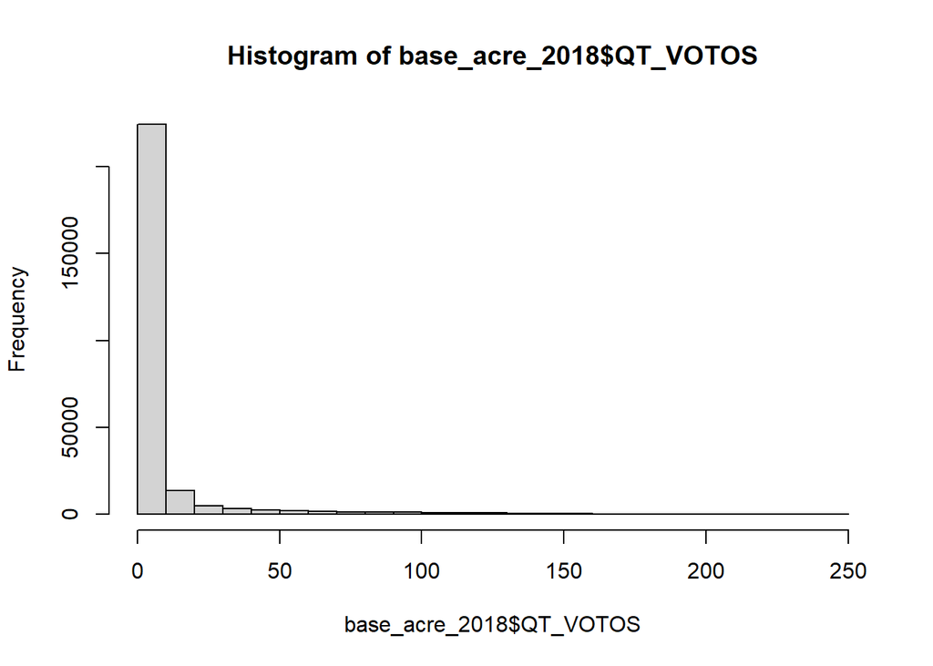

```r
hist(base_acre_2018$QT_VOTOS)
```

### 2. Selecionando variáveis

Podemos ver que são muitas linhas e muitas colunas. Colunas que nem sempre trazem informação necessária para nós. Vamos selecionar apenas as que nos interessam: ANO_ELEICAO, NR_TURNO, DS_CARGO,NM_MUNICIPIO, NM_VOTAVEL, QT_VOTOS

```r
base <- base_acre_2018 %>%
  select(ANO_ELEICAO, NR_TURNO, DS_CARGO,NM_MUNICIPIO, NM_VOTAVEL, QT_VOTOS)
```

*Leia-se* Eu estou atribuindo ao um novo objeto *data.frame* chamado *base*, uma versão de *base_acre_2018*, onde está selecionada as seguintas colunas: ANO_ELEICAO, NR_TURNO, DS_CARGO,NM_MUNICIPIO, NM_VOTAVEL, QT_VOTOS

*Atenção* Neste código utilizamos um outro elemento, o *pipe*, %>% . Este é um operador que vem com o pacote *tidyverse*, logo só podemos operá-lo uma vez que esteja carregado. Ele nos permite escrever de forma mais fluída as operações que desejamos rodar. Este mesmo código poderia ser escrito em *R base*, da seguinte forma:

```r
select(base_acre_2018, ANO_ELEICAO, NR_TURNO, DS_CARGO,NM_MUNICIPIO, NM_VOTAVEL, QT_VOTOS)
```

```
##       ANO_ELEICAO NR_TURNO          DS_CARGO         NM_MUNICIPIO
## 1            2018        1 DEPUTADO ESTADUAL            BRASILÉIA
## 2            2018        1 DEPUTADO ESTADUAL           RIO BRANCO
## 3            2018        1 DEPUTADO ESTADUAL           RIO BRANCO
## 4            2018        1           SENADOR           RIO BRANCO
## 5            2018        1  DEPUTADO FEDERAL           RIO BRANCO
## 6            2018        1  DEPUTADO FEDERAL     SENADOR GUIOMARD
## 7            2018        1 DEPUTADO ESTADUAL           RIO BRANCO
## 8            2018        1 DEPUTADO ESTADUAL           RIO BRANCO
## 9            2018        1           SENADOR           RIO BRANCO
## 10           2018        1 DEPUTADO ESTADUAL      CRUZEIRO DO SUL
## 11           2018        1 DEPUTADO ESTADUAL                FEIJÓ
## 12           2018        1 DEPUTADO ESTADUAL           RIO BRANCO
## 13           2018        1  DEPUTADO FEDERAL           RIO BRANCO
## 14           2018        1 DEPUTADO ESTADUAL                FEIJÓ
```

[output cut: 33320 more lines]

Pode não pareceber tão diferente, com apenas uma função. Mas veremos no final como o *tidyverse* *otimiza* o código de forma que rodamos várias funções de uma única vez.

Uma vez que você rode este código, em seu “Environment” estarão os dois *data.frame*, o que foi importado e um novo, que acabou de ser criado. O bom de criar um novo objeto ao realizar uma alteração muito significativa é que, caso ocorra algum engano, não precisamos importar novamente a base. Quando criamos uma nova base, a partir de alguma modificação que desejamos realizar, evitamos sobrescrever o objeto. Não perdemos o original.

Vamos olhar novamente como está nossa base:

```r
head(base)
```

```
##   ANO_ELEICAO NR_TURNO          DS_CARGO     NM_MUNICIPIO
## 1        2018        1 DEPUTADO ESTADUAL        BRASILÉIA
## 2        2018        1 DEPUTADO ESTADUAL       RIO BRANCO
## 3        2018        1 DEPUTADO ESTADUAL       RIO BRANCO
## 4        2018        1           SENADOR       RIO BRANCO
## 5        2018        1  DEPUTADO FEDERAL       RIO BRANCO
## 6        2018        1  DEPUTADO FEDERAL SENADOR GUIOMARD
##                           NM_VOTAVEL QT_VOTOS
## 1         MARCOS TIBURCIO DOS SANTOS        2
## 2   JOÃO BATISTA FERREIRA DOS SANTOS        2
## 3            ALEDIAS SOARES DE SOUZA        1
## 4               JOZINEY ALVES AMORIM       59
## 5 Partido Humanista da Solidariedade        1
## 6   CYLMARA FERNANDES DA ROCHA GRIPP       14
```

### 3. Selecionando linhas

Sabemos que nas eleições de 2018, vários cargos estavam em disputa. Quais são eles?

```r
unique(base$DS_CARGO) #utilizando R base com uma funçaõ que nos retorna os valores ÚNICOS da coluna DS_CARGO
```

```
## [1] "DEPUTADO ESTADUAL" "SENADOR"           "DEPUTADO FEDERAL"
## [4] "GOVERNADOR"
```

Vamos trabalhar só com Deputado Federal. Para isso devemos filtrar apenas as linhas de DS_CARGO que contenam “DEPUTADO FEDERAL”

```r
base <- base %>%
  filter(DS_CARGO == "DEPUTADO FEDERAL")
```

Repare que eu utilizo o operador relacional == para que o R apenas as linhas exatas que contém os candidatos ao cargo de deputado federal.

Se, por acaso, o nosso recorte, o nosso filtro, fosse quantidade de votos, poderíamos utilizar o seguinte código:

```r
base %>%
  filter(QT_VOTOS >= 150)
```

```
##   ANO_ELEICAO NR_TURNO         DS_CARGO         NM_MUNICIPIO
## 1        2018        1 DEPUTADO FEDERAL      CRUZEIRO DO SUL
## 2        2018        1 DEPUTADO FEDERAL      RODRIGUES ALVES
## 3        2018        1 DEPUTADO FEDERAL             TARAUACÁ
## 4        2018        1 DEPUTADO FEDERAL MARECHAL THAUMATURGO
##                  NM_VOTAVEL QT_VOTOS
## 1       JESSICA ROJAS SALES      175
## 2       JESSICA ROJAS SALES      172
## 3       JESSICA ROJAS SALES      184
## 4 FRANCISCO DA SILVA PIYÃKO      164
```

No cósido acima, eu não atribui, não utilizei “<-”, a um objeto. Logo, o R me retornou um *data.frame* no console, mas ele não foi salvo. Meu objeto *base* não foi alterado por esse filtro em específico.

Vamos olhar como está a nossa base novamente:

```r
glimpse(base)
```

```
## Rows: 82,223
## Columns: 6
## $ ANO_ELEICAO  <int> 2018, 2018, 2018, 2018, 2018, 2018, 2018, 2018, 2018, 201~
## $ NR_TURNO     <int> 1, 1, 1, 1, 1, 1, 1, 1, 1, 1, 1, 1, 1, 1, 1, 1, 1, 1, 1, ~
## $ DS_CARGO     <chr> "DEPUTADO FEDERAL", "DEPUTADO FEDERAL", "DEPUTADO FEDERAL~
## $ NM_MUNICIPIO <chr> "RIO BRANCO", "SENADOR GUIOMARD", "RIO BRANCO", "CRUZEIRO~
## $ NM_VOTAVEL   <chr> "Partido Humanista da Solidariedade", "CYLMARA FERNANDES ~
## $ QT_VOTOS     <int> 1, 14, 1, 2, 1, 6, 1, 18, 9, 6, 3, 1, 2, 1, 47, 3, 4, 1, ~
```

### 4. Agrupando informações

Olhando a nossa base, vemos que o nome dos candidatos se repetem por todos os muninícipio que eles foram votados. Para conhecer o voto total de cada candidato temos que sumarizar a coluna QT_VOTOS.

```r
base %>%
  group_by(NM_VOTAVEL) %>%
  summarise(voto_candidato = sum(QT_VOTOS))
```

```
## # A tibble: 116 x 2
##    NM_VOTAVEL                             voto_candidato
##    <chr>                                           <int>
##  1 ADRIANO JOSÉ CALDAS DE AGUIAR CAMPELLO            766
##  2 ALAN RICK MIRANDA                               22263
##  3 ANA PAULA BATISTA POZENATTO                         6
##  4 ANDRESA DA SILVA CASTRO BARROS                    355
##  5 ANTONIO PAULINO DA SILVA                          214
##  6 ANTÔNIA LUCILÉIA CRUZ RAMOS CÂMARA              15336
##  7 AVANTE                                             27
##  8 BERENICE NASCIMENTO DE SOUZA                       98
##  9 CARLOS CÉSAR CORREIA DE MESSIAS                 10769
## 10 CARLOS GOMES DA COSTA SOUZA                      5414
## # i 106 more rows
```

Vamos, agora, observar o total de votos válidos nos munucípios:

```r
base %>%
  group_by(NM_MUNICIPIO) %>%
  summarise(voto_valido_municipio = sum(QT_VOTOS))
```

```
## # A tibble: 22 x 2
##    NM_MUNICIPIO    voto_valido_municipio
##    <chr>                           <int>
##  1 ACRELÂNDIA                       7260
##  2 ASSIS BRASIL                     4592
##  3 BRASILÉIA                       13435
##  4 BUJARI                           6993
##  5 CAPIXABA                         5851
##  6 CRUZEIRO DO SUL                 45577
##  7 EPITACIOLÂNDIA                   9243
##  8 FEIJÓ                           14573
##  9 JORDÃO                           3581
## 10 MANOEL URBANO                    4926
## # i 12 more rows
```

Mas note que com o recurso summarizar, perdemos as outras colunas. Então, é válido que aqui criemos um novo objeto para não subescrever o anterior. Seguimos, então, com voto por município.

```r
base_municipio <- base %>%
  group_by(NM_MUNICIPIO) %>%
  summarise(voto_valido_municipio = sum(QT_VOTOS))
```

Podemos acrescentar novas colunas usando a função *mutate*, responsável por criar colunas, e adicionar novamente informações

```r
base_municipio <- base_municipio %>%
  mutate(UF = "Acre",
         Eleicao = 2018)
```

Podemos extrair algumas estatíticas descritivas

```r
summary(base_municipio)
```

```
##  NM_MUNICIPIO       voto_valido_municipio      UF               Eleicao
##  Length:22          Min.   :  2342        Length:22          Min.   :2018
##  Class :character   1st Qu.:  6136        Class :character   1st Qu.:2018
##  Mode  :character   Median :  9405        Mode  :character   Median :2018
##                     Mean   : 20156                           Mean   :2018
##                     3rd Qu.: 14288                           3rd Qu.:2018
##                     Max.   :211844                           Max.   :2018
```

- Vamos recapitular os últimos passos, porém em um único bloco de comandos com o pipe. Se atente que em programação, a ordem dos fatores altera o produto.

```r
base_municipio2 <- base_acre_2018 %>%
  select(ANO_ELEICAO, NR_TURNO, DS_CARGO,NM_MUNICIPIO, NM_VOTAVEL, QT_VOTOS) %>%
  filter(DS_CARGO == "DEPUTADO FEDERAL") %>%
  group_by(NM_MUNICIPIO) %>%
  summarise(voto_valido_municipio = sum(QT_VOTOS)) %>%
  mutate(UF = "Acre", Eleicao = 2018)
```

Temos como resultado, a mesma base

```r
head(base_municipio2)
```

```
## # A tibble: 6 x 4
##   NM_MUNICIPIO    voto_valido_municipio UF    Eleicao
##   <chr>                           <int> <chr>   <dbl>
## 1 ACRELÂNDIA                       7260 Acre     2018
## 2 ASSIS BRASIL                     4592 Acre     2018
## 3 BRASILÉIA                       13435 Acre     2018
## 4 BUJARI                           6993 Acre     2018
## 5 CAPIXABA                         5851 Acre     2018
## 6 CRUZEIRO DO SUL                 45577 Acre     2018
```

### 5. Exportando a base

Para exportar, utilizaremos outra função do pacote *rio*. O funcionamento é muito parecido com o da importação. O importante é se atentar ao objeto que vai ser usado e qual o caminho você quer que ele tome.

Se eu quero exportar para alguma pasta específica, nesse caso, “Downloads”, eu utilizaria o seguinte caminho:

```r
export(base_municipio, "C:\\Users\\Lua\\Downloads\\base_final.csv") #São dois argumento: 1. o caminho de destino da base com o nome que eu quero exportar + o tipo (.csv); 2. o objeto
??export
```

mas se eu quero exportar para a pasta onde está o script:

```r
export(base_municipio, "base_final.csv")
```

Reparem que eu escrevi “base_final.csv”. Isso porque eu posso nomear da forma que quiser este objeto quando expotá-lo. Não precisa ser o mesmo utilizado dentro do ambiente do Rstudio.

## Dicas finais

**Programação é prática!**

Recomendo que utilizem os livros que estão disponíveis online, leiam e reescrevam os códigos deles.

o [Curso-R](https://livro.curso-r.com/3-2-r-como-calculadora.html) e [Introdução a Linguaguem R](https://pedropark99.github.io/Introducao_R/index.html) possuem exercícios para vocês praticarem!

Obrigada!!

## Referências

DAMIANIE, et al. Ciência de dados em R. https://livro.curso-r.com/index.html. 2022

https://medium.com/ibmec-quant/iniciando-os-estudos-em-r-50667364fff4

http://cursos.leg.ufpr.br/ecr/

DAURICIO, Juliana. Algoritmos e Lógica de Programação. Editora Educacional. Londrina, 2015

MEIRELES, Fernando e SILVA, Denisson. Usando R: Um Guia para Cientistas Políticos http://electionsbr.com/livro/index.html . 2018

WICKHAM, Hadley e GROLEMUND, Garret. R for Data Science https://r4ds.had.co.nz/index.html. 2017

FARIA, Pedro Duarte. Introdução à Linguagem R: seus fundamentos e sua prática. 4. ed. Belo Horizonte: [s.n.], 2022. ISBN 978-65-00-57872-0. Disponível em: https://pedropark99.github.io/Introducao_R/